# Time Series on Yearly Expenditure of Eating Out in Australia

## 2.3 Correlation

Checking the correlation by plotting the scatter plot of the time series.

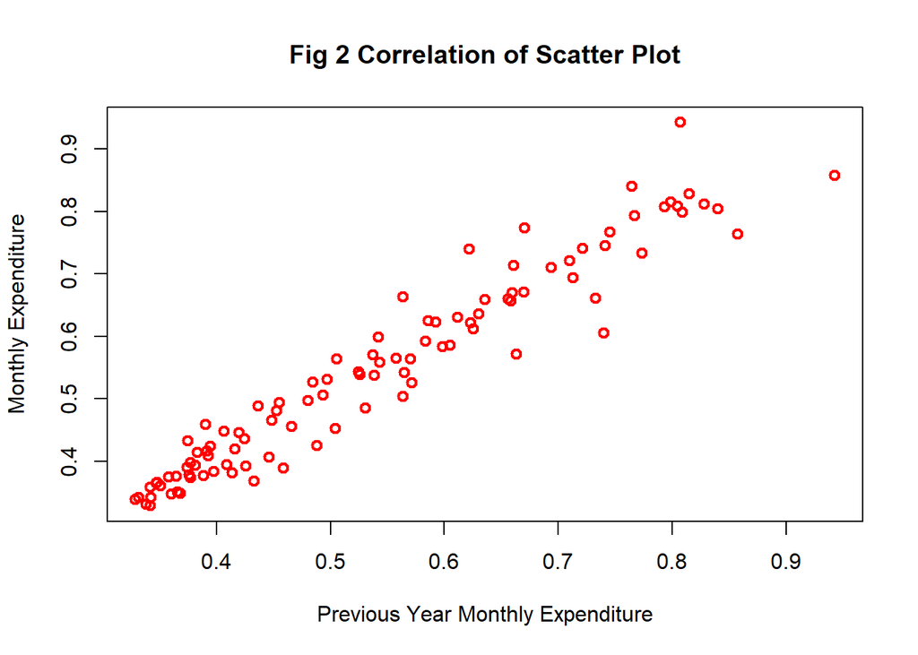

```r
plot(y=cafe.ts,x=zlag(cafe.ts),ylab='Monthly Expenditure', xlab='Previous Year Monthly Expenditure',
     col='Red',lwd=2,main='Fig 2 Correlation of Scatter Plot')
```

From the above, scatter plot we can see auto-correlation is present. Let us see the pearson coefficient for the correlation.

## 2.4 Pearson coefficient

```r
y = cafe.ts
x = zlag(cafe.ts)
index = 2:length(x)
cor(y[index],x[index])
```

```
## [1] 0.9639352
```

From the above scatter plot and the pearson coefficient, Linear upward trend and high correlation of 0.96 is observed.

## 2.5 ACF and PACF

We plot ACF to see the correlation of the data points on their previous values. Let us see at the lags and find out.

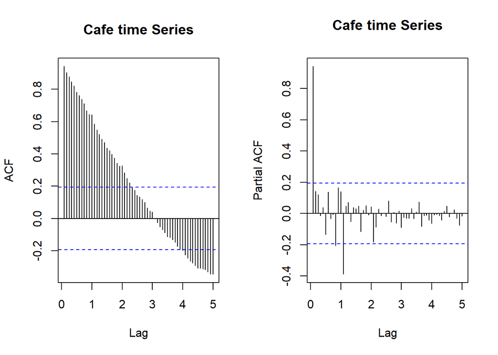

```r
par(mfrow=c(1,2))
acf(cafe.ts,lag.max = 60,main="Cafe time Series")
pacf(cafe.ts,lag.max = 60,main="Cafe time Series")
```

Following deductions are made from the ACF and PACF plot above:

From this we infer the non-seasonal AR(1 or 2) model (correlation at low lags).

## 2.6 ADF Test and Shapiro-Wilk Test

Now, we perform the Augmented Dickey Fuller test, which determines whether the series is stationary or not. H0 - The given time series is not stationary. H1 - The given time series is stationary. Moreover, we do the Shapiro Wilk test to determine the normality of the time series

```r
adf.test(cafe.ts)
```

```
##
##  Augmented Dickey-Fuller Test
##
## data:  cafe.ts
## Dickey-Fuller = -2.7878, Lag order = 4, p-value = 0.2501
## alternative hypothesis: stationary
```

```r
#As p greater than 0.05
#Non stationarity evidence
shapiro.test(cafe.ts)
```

```
##
##  Shapiro-Wilk normality test
##
## data:  cafe.ts
## W = 0.93523, p-value = 8.486e-05
```

```r
#Not normally distributed
```

## 2.7 Modeling ARIMA

As we can see, the data is non-stationary and evidence of seasonality is present we will try SARIMA models. As far as, the normality of data is concerned, we will be doing log transformation of the time series. First of all, We will do the seasonal differencing to get rid of seasonal trend and fitting a plain model until time series and ACF/PACF plots of residuals show no sign of seasonality.

Taking the first seasonal difference, and seeing if the seasonal trend still exists.

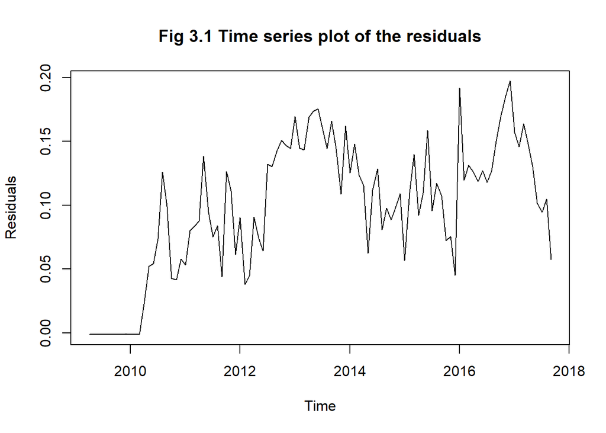

```r
m1.cafe = arima(log(cafe.ts),order=c(0,0,0),seasonal=list(order=c(0,1,0), period=12))
res.m1 = residuals(m1.cafe);
par(mfrow=c(1,1))
plot(res.m1,xlab='Time',ylab='Residuals',main="Fig 3.1 Time series plot of the residuals")
```

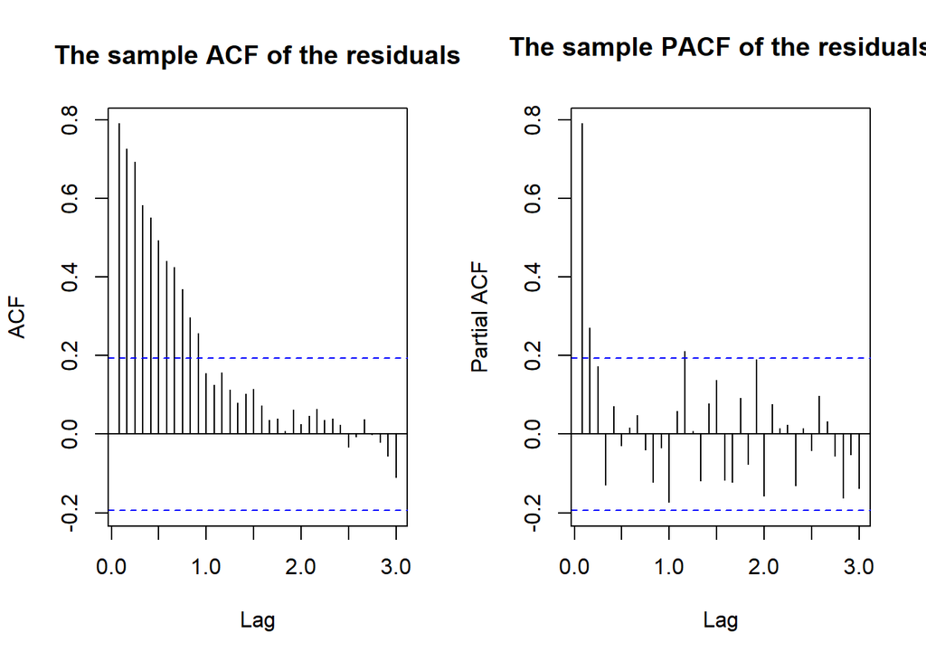

```r
par(mfrow=c(1,2))
acf(res.m1, lag.max = 36, main = "The sample ACF of the residuals")
pacf(res.m1, lag.max = 36, main = "The sample PACF of the residuals")
```

There exists a trend as evident by the ts plot. Moreover, trend and seasonality is still seen. As there exists a sinusoidal pattern we need to take ordinary difference.

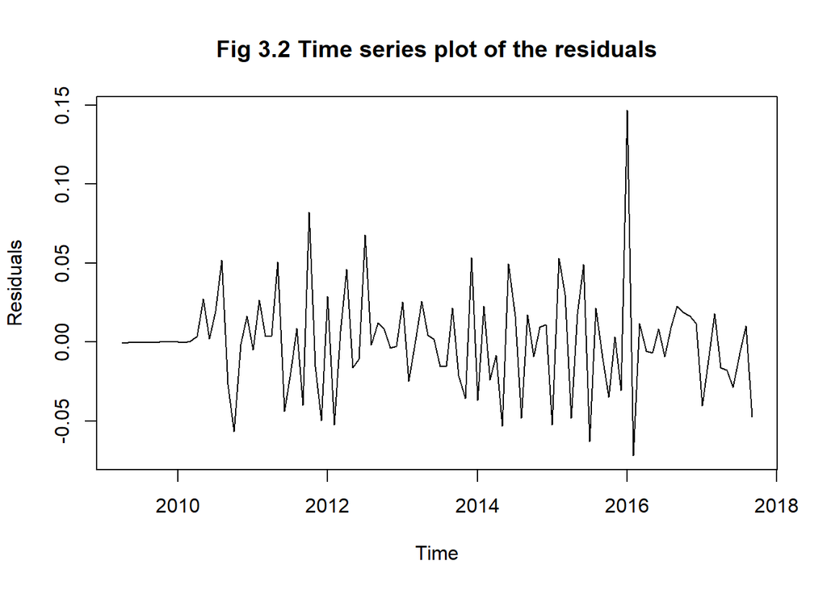

```r
m2.cafe = arima(log(cafe.ts),order=c(0,1,0),seasonal=list(order=c(0,1,0), period=12))
res.m2 = residuals(m2.cafe);
par(mfrow=c(1,1))
plot(res.m2,xlab='Time',ylab='Residuals',main="Fig 3.2 Time series plot of the residuals")
```

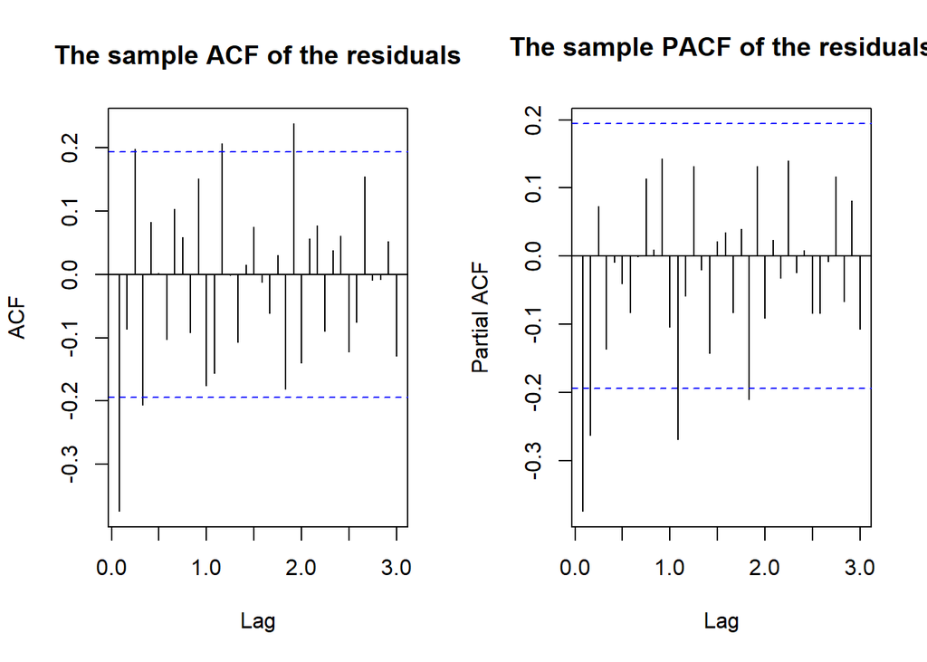

```r
par(mfrow=c(1,2))
acf(res.m2, lag.max = 36, main = "The sample ACF of the residuals")
pacf(res.m2, lag.max = 36, main = "The sample PACF of the residuals")
```

We can see the model is much improved. Although some lags still exists. We will eliminate these lags by taking the AR and MA component as required. Also, the model looks stationary. we see seasonal lags (1.2) in both ACF and PACF plot indicating SARMA(1,1).

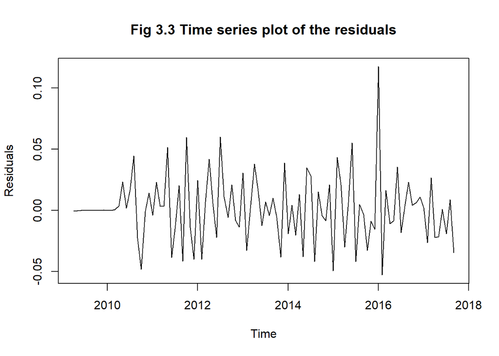

```r
m3.cafe = arima(log(cafe.ts),order=c(0,1,0),seasonal=list(order=c(1,1,1), period=12))
res.m3 = residuals(m3.cafe);
par(mfrow=c(1,1))
plot(res.m3,xlab='Time',ylab='Residuals',main="Fig 3.3 Time series plot of the residuals")
```

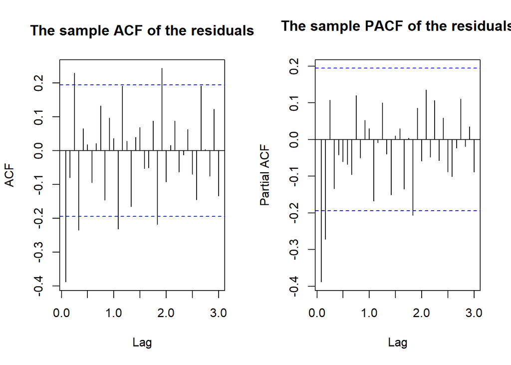

```r
par(mfrow=c(1,2))
acf(res.m3, lag.max = 36, main = "The sample ACF of the residuals")
pacf(res.m3, lag.max = 36, main = "The sample PACF of the residuals")
```

Correlation is still present on seasonal lag (in ACF plot). We use high number of Q (MA) until filtering out seasonal lags.

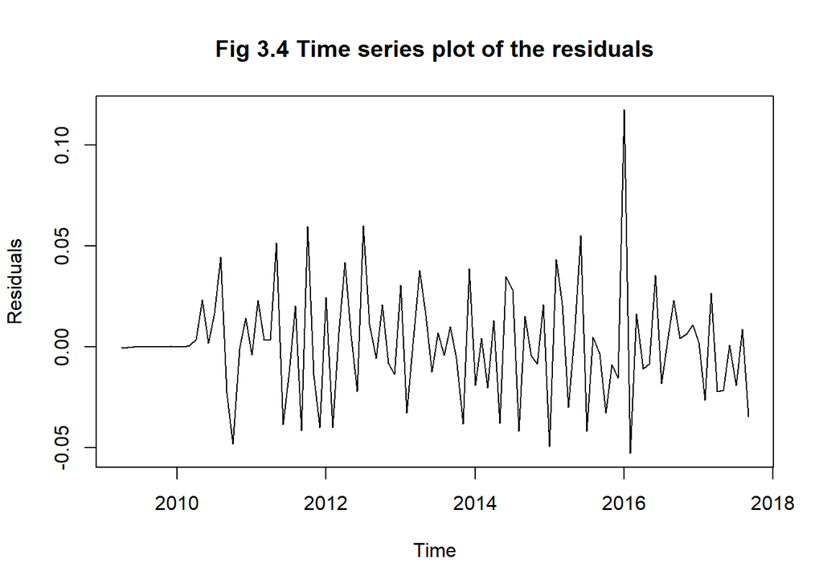

```r
m4.cafe = arima(log(cafe.ts),order=c(0,1,0),seasonal=list(order=c(1,1,2), period=12))
res.m4 = residuals(m4.cafe);
par(mfrow=c(1,1))
plot(res.m3,xlab='Time',ylab='Residuals',main="Fig 3.4 Time series plot of the residuals")
```

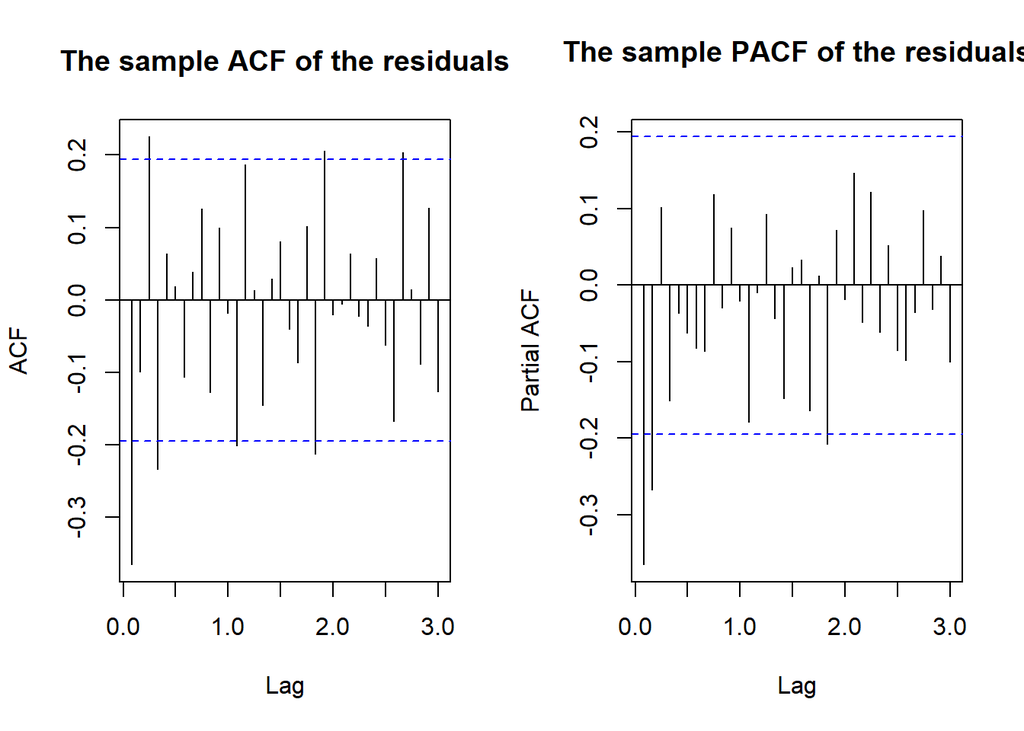

```r
par(mfrow=c(1,2))
acf(res.m4, lag.max = 36, main = "The sample ACF of the residuals")
pacf(res.m4, lag.max = 36, main = "The sample PACF of the residuals")
```

To verify the stationarity adf test was used and we found the series stationary.

```r
adf.test(res.m4)
```

```
##
##  Augmented Dickey-Fuller Test
##
## data:  res.m4
## Dickey-Fuller = -5.3802, Lag order = 4, p-value = 0.01
## alternative hypothesis: stationary
```

Our model quite gracefully qualifies the stationarity test.

# 3 Model Fitting

We are restricting EACF to 3 in both AR and MA parameters. Let us now take a look at the eacf to find the best candidate models.

```r
## EACF
eacf(res.m4, ar.max = 3, ma.max = 3)
```

```
## AR/MA
##   0 1 2 3
## 0 x o x x
## 1 x x o o
## 2 x o o o
## 3 x x o o
```

The possible models are:- - SARMA(2,1,0)(1,1,2) by ACF/PACF - SARMA(0,1,1)(1,1,2) by EACF - SARMA(1,1,2)(1,1,2) by EACF - SARMA(2,1,1)(1,1,2) by EACF - SARMA(3,1,2)(1,1,2) by EACF

# 4 Parameter Estimation

We will now apply the coefficient test on all the candidate models to get the best possible outcome.

```r
model1.cafe = arima(log(cafe.ts),order=c(2,1,0),seasonal=list(order=c(1,1,2), period=12),method = "ML")
coeftest(model1.cafe)
```

```
##
## z test of coefficients:
##
##       Estimate Std. Error z value  Pr(>|z|)
## ar1  -0.509080   0.107502 -4.7355 2.185e-06 ***
## ar2  -0.282732   0.102599 -2.7557  0.005857 **
## sar1  0.295936   0.310586  0.9528  0.340676
## sma1 -0.906319   0.338083 -2.6808  0.007346 **
## sma2 -0.093653   0.281965 -0.3321  0.739781
## ---
## Signif. codes:  0 '***' 0.001 '**' 0.01 '*' 0.05 '.' 0.1 ' ' 1
```

Model1 (2,1,0)(1,1,2) summary: Both the non-seasonal components are significant as the p-value is below 0.05

```r
model2.cafe = arima(log(cafe.ts),order=c(0,1,1),seasonal=list(order=c(1,1,2), period=12),method = "ML")
coeftest(model2.cafe)
```

```
##
## z test of coefficients:
##
##      Estimate Std. Error z value  Pr(>|z|)
## ma1  -0.52580    0.10126 -5.1924 2.076e-07 ***
## sar1  0.29559    0.28963  1.0206  0.307445
## sma1 -0.88177    0.31503 -2.7990  0.005126 **
## sma2 -0.11804    0.25862 -0.4564  0.648093
## ---
## Signif. codes:  0 '***' 0.001 '**' 0.01 '*' 0.05 '.' 0.1 ' ' 1
```

Model2 (0,1,1)(1,1,2) summary: The non-seasonal components are significant as the p-value is below 0.05

```r
model3.cafe = arima(log(cafe.ts),order=c(1,1,2),seasonal=list(order=c(1,1,2), period=12),method = "ML")
coeftest(model3.cafe)
```

```
##
## z test of coefficients:
##
##       Estimate Std. Error  z value  Pr(>|z|)
## ar1  -0.829835   0.069387 -11.9596 < 2.2e-16 ***
## ma1   0.432926   0.115621   3.7443 0.0001809 ***
## ma2  -0.566947   0.105448  -5.3766 7.592e-08 ***
## sar1  0.243985   0.296819   0.8220 0.4110779
## sma1 -0.825906   0.324799  -2.5428 0.0109961 *
## sma2 -0.174085   0.264959  -0.6570 0.5111638
## ---
## Signif. codes:  0 '***' 0.001 '**' 0.01 '*' 0.05 '.' 0.1 ' ' 1
```

Model3 (1,1,2)(1,1,2) summary: All the non-seasonal components are significant as the p-value is below 0.05

```r
model4.cafe = arima(log(cafe.ts),order=c(2,1,1),seasonal=list(order=c(1,1,2), period=12),method = "ML")
coeftest(model4.cafe)
```

```
##
## z test of coefficients:
##
##      Estimate Std. Error z value  Pr(>|z|)
## ar1  -1.00394    0.24755 -4.0555 5.003e-05 ***
## ar2  -0.47271    0.10448 -4.5246 6.052e-06 ***
## ma1   0.56035    0.28095  1.9945   0.04610 *
## sar1  0.24068    0.34769  0.6922   0.48879
## sma1 -0.87757    0.37124 -2.3639   0.01808 *
## sma2 -0.12240    0.31816 -0.3847   0.70046
## ---
## Signif. codes:  0 '***' 0.001 '**' 0.01 '*' 0.05 '.' 0.1 ' ' 1
```

```r
model5.cafe = arima(log(cafe.ts),order=c(3,1,2),seasonal=list(order=c(1,1,2), period=12),method = "ML")
coeftest(model5.cafe)
```

```
##
## z test of coefficients:
##
##      Estimate Std. Error z value Pr(>|z|)
## ar1  -0.31984    0.39418 -0.8114  0.41713
## ar2   0.32868    0.31085  1.0573  0.29036
## ar3   0.31542    0.19074  1.6537  0.09820 .
## ma1  -0.16295    0.39099 -0.4168  0.67686
## ma2  -0.58021    0.23451 -2.4741  0.01336 *
## sar1  0.21420    0.34764  0.6162  0.53778
## sma1 -0.84287    0.37053 -2.2748  0.02292 *
## sma2 -0.15696    0.31726 -0.4947  0.62079
## ---
## Signif. codes:  0 '***' 0.001 '**' 0.01 '*' 0.05 '.' 0.1 ' ' 1
```

## 4.1 AIC & BIC

```r
sc.AIC=AIC(model1.cafe, model2.cafe, model3.cafe, model4.cafe, model5.cafe)
sc.BIC=AIC(model1.cafe, model2.cafe, model3.cafe, model4.cafe, model5.cafe)
sort.score(sc.AIC, score = "aic")
```

```
##             df       AIC
## model3.cafe  7 -371.7448
## model2.cafe  5 -371.2308
## model4.cafe  7 -371.2242
## model1.cafe  6 -370.8633
## model5.cafe  9 -368.8027
```

```r
sort.score(sc.BIC, score = "aic")
```

```
##             df       AIC
## model3.cafe  7 -371.7448
## model2.cafe  5 -371.2308
## model4.cafe  7 -371.2242
## model1.cafe  6 -370.8633
## model5.cafe  9 -368.8027
```

## 4.2 Testing for Overfitting

```r
model0.cafe = arima(log(cafe.ts),order=c(3,1,4),seasonal=list(order=c(1,1,2), period=12),method = "ML")
coeftest(model0.cafe)
```

```
##
## z test of coefficients:
##
##       Estimate Std. Error z value Pr(>|z|)
## ar1  -0.565076   0.597279 -0.9461  0.34411
## ar2  -0.389682   0.664218 -0.5867  0.55742
## ar3   0.543999   0.596672  0.9117  0.36192
## ma1   0.144128   0.621490  0.2319  0.81661
## ma2   0.124881   0.381492  0.3273  0.74340
## ma3  -0.784909   0.298588 -2.6287  0.00857 **
## ma4   0.142358   0.324454  0.4388  0.66083
## sar1  0.082386   0.446471  0.1845  0.85360
## sma1 -0.789876   0.471683 -1.6746  0.09401 .
## sma2 -0.209862   0.403777 -0.5197  0.60324
## ---
## Signif. codes:  0 '***' 0.001 '**' 0.01 '*' 0.05 '.' 0.1 ' ' 1
```

```r
defaultW <- getOption("warn")
options(warn = -1)

residual.analysis(model=model0.cafe)
```

```
##
##  Shapiro-Wilk normality test
##
## data:  res.model
## W = 0.94875, p-value = 0.0005968
```

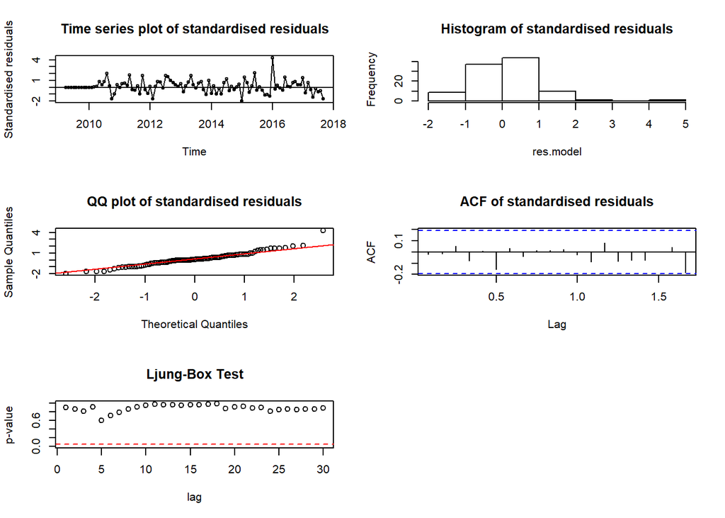

```r
options(warn = defaultW)
```

## 4.3 Diagnostic Check for the selected Best model

```r
defaultW <- getOption("warn")
options(warn = -1)

residual.analysis(model=model3.cafe)
```

```
##
##  Shapiro-Wilk normality test
##
## data:  res.model
## W = 0.97, p-value = 0.02012
```

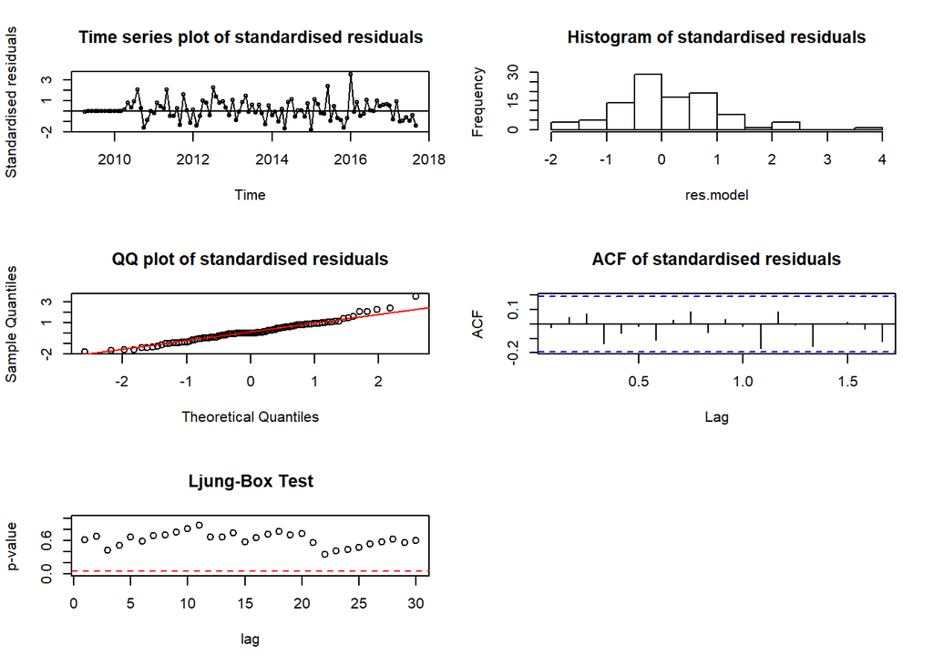

```r
options(warn = defaultW)
```

# 5 Forecasting

Now, we will do the forecasting for next 12 months. Choosing our best model which model3 (1,1,2)(1,1,2). We will use sarima.for function from astsa package.

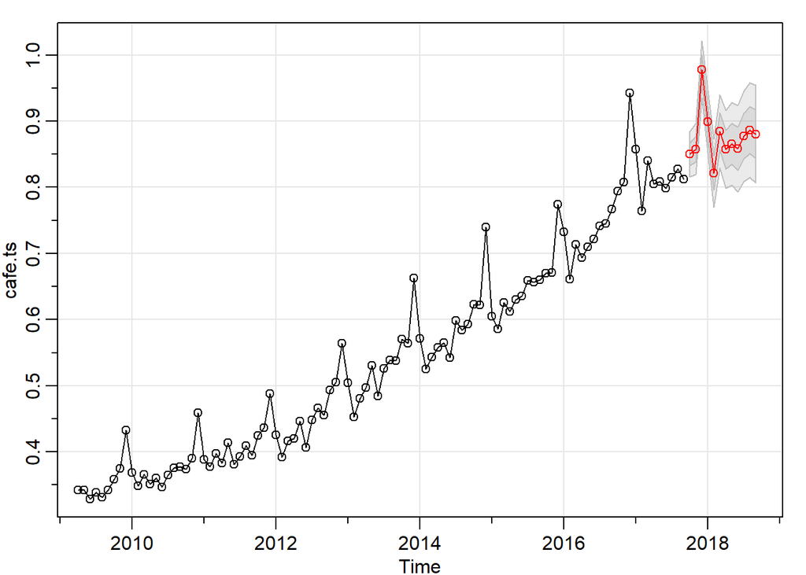

```
## $pred
##            Jan       Feb       Mar       Apr       May       Jun       Jul
## 2017
## 2018 0.8993687 0.8214606 0.8845838 0.8573898 0.8657102 0.8585148 0.8771265
##            Aug       Sep       Oct       Nov       Dec
## 2017                     0.8501896 0.8577623 0.9779847
## 2018 0.8864201 0.8804407
##
## $se
##             Jan        Feb        Mar        Apr        May        Jun
## 2017
## 2018 0.02367942 0.02573132 0.02763359 0.02941240 0.03108880 0.03267933
##             Jul        Aug        Sep        Oct        Nov        Dec
## 2017                                  0.01734846 0.01910597 0.02145185
## 2018 0.03419595 0.03564812 0.03704340
```

```r
defaultW <- getOption("warn")
options(warn = -1)

# "Forecast for the next 12 months"
sarima.for(cafe.ts,12,1,1,2,1,1,2,12)
```

```r
options(warn = defaultW)
```

The above plot is approached by seasonality. We can see the forecast matches the Pattern.

# 6 Conclusion

Atlast, we did the forecasting for the next 12 months using our best model. We found that our forecast follow the trend as previous years that is a upward trend. Therefore, the restaurants are likely to get busier in the coming future. As the economy increases the food business will also have an positive effect of that. Moreover, as the dataset showed seasonality we used SARIMA model which turned out to be a good choice.

# 7 Summary

# 8 References

[1] Demirhan, H. Ph.D. Time Series in R. [online] Canvas. Available at: https://rmit.instructure.com/courses/79716/modules [Accessed 13 June 2021].

[2] Cafe: Quarterly expenditure on eating out in Australia in fpp: Data for “Forecasting: principles and practice”. [online] Rdrr.io. Available at: https://rdrr.io/cran/fpp/man/cafe.html [Accessed 13 June 2021].